# Biostat M280 Homework 2

Due Feb 16 @ 11:59PM

Lumi Huang

## Q1

Read [Chapter 7](http://r4ds.had.co.nz/exploratory-data-analysis.html) (Exploratory Data Analysis) of *R for Data Science* and do exercises 7.3.4, 7.4.1, 7.5.1.1, 7.5.2.1, and 7.5.3.1.

7.3.4 1.Explore the distribution of each of the x, y, and z variables in diamonds. What do you learn? Think about a diamond and how you might decide which dimension is the length, width, and depth.

```r
#packages
if (!require("tidyverse"))
     install.packages("tidyverse", repos='http://cran.us.r-project.org')
if (!require("forcats"))
     install.packages("forcats", repos='http://cran.us.r-project.org')
if (!require("nycflights13"))
     install.packages("nycflights13", repos='http://cran.us.r-project.org')
library(tidyverse)
library(forcats)
library(nycflights13)
```

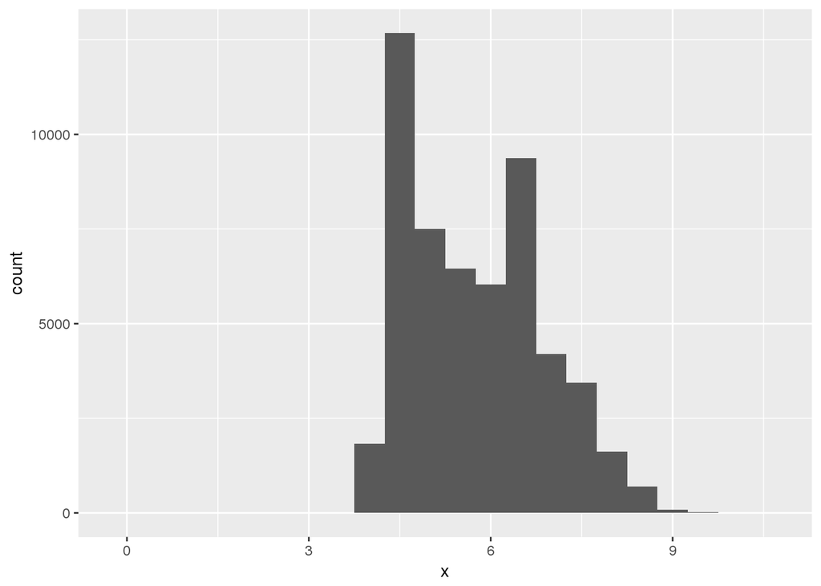

```r
#examining the distribution of x, y, z
ggplot(data = diamonds) + geom_histogram(mapping = aes(x), binwidth = 0.5)
```

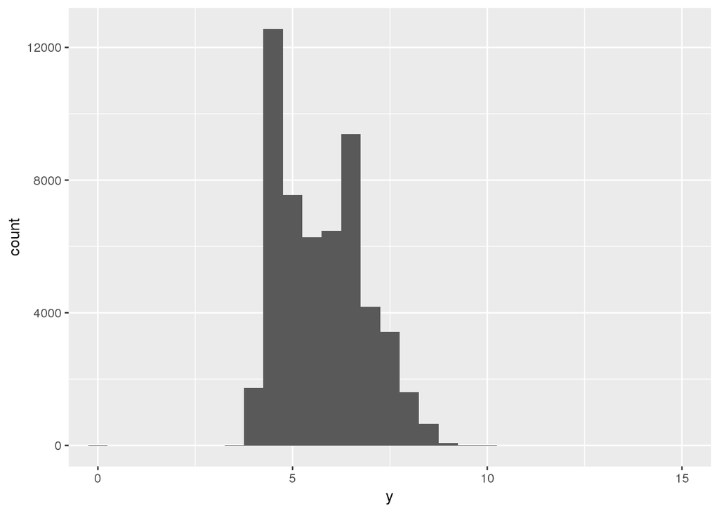

```r
ggplot(data = diamonds) + geom_histogram(mapping = aes(y), binwidth = 0.5) +
  coord_cartesian(xlim = c(0, 15))
```

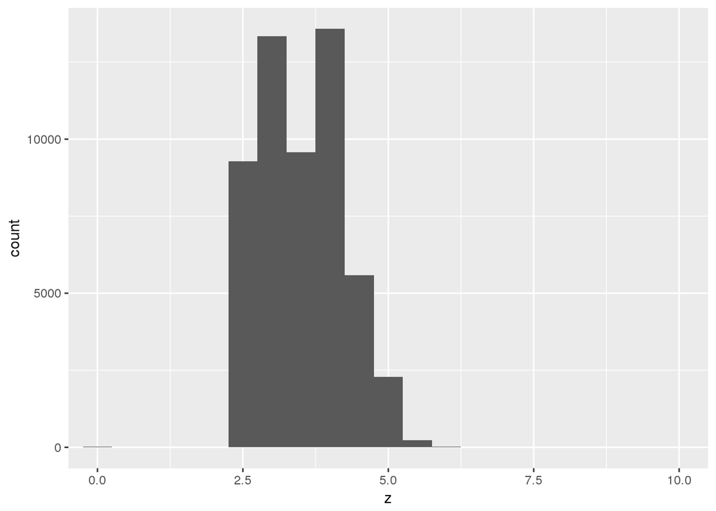

```r
ggplot(data = diamonds) + geom_histogram(mapping = aes(z), binwidth = 0.5) +
  coord_cartesian(xlim = c(0, 10))
```

I learnt that there are some outliers in y and z by the evidence of the unusually wide limits on the x-axis. Based on the distribution of x, y, z without outliers, we can say x, y are the length and width of diamonds, and z is the depth of diamonds.

2.Explore the distribution of price. Do you discover anything unusual or surprising? (Hint: Carefully think about the binwidth and make sure you try a wide range of values.)

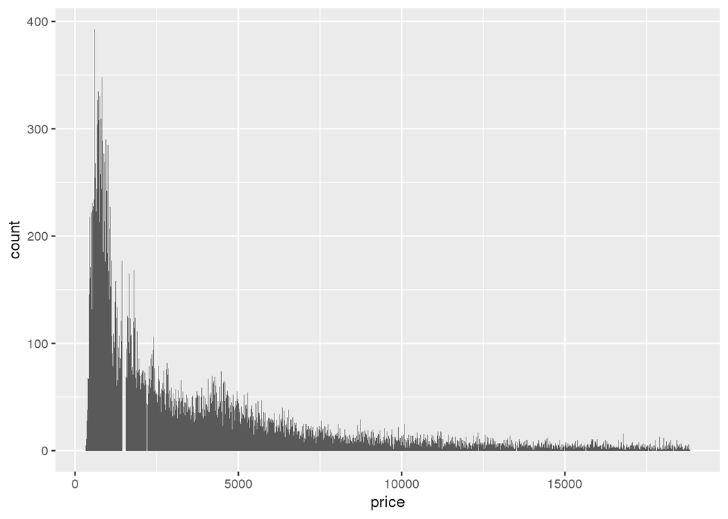

```r
#small value for binwidth
ggplot(data = diamonds) +
  geom_histogram(mapping = aes(x = price), binwidth = 10)
```

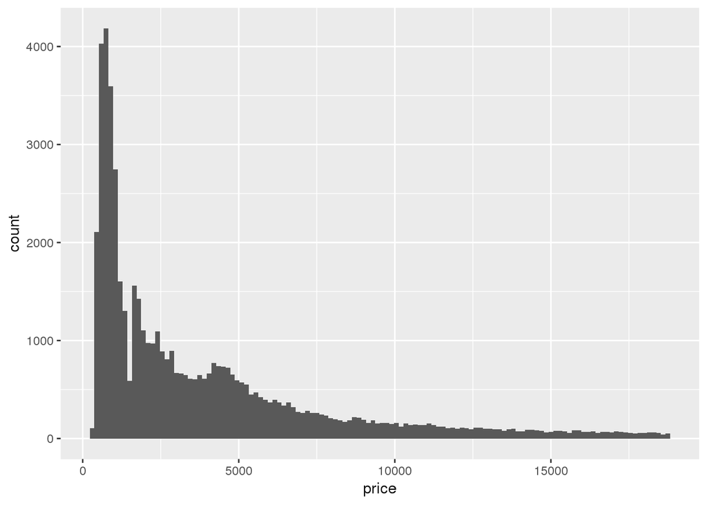

```r
#try a wide range of values
ggplot(data = diamonds) +
  geom_histogram(mapping = aes(x = price), binwidth = 150)
```

The distribution of price is very positively skewed. It looks like there is a lower bound for the price of diamonds based on the distribution of price.

3.How many diamonds are 0.99 carat? How many are 1 carat? What do you think is the cause of the difference?

```r
carat_0.99 <- diamonds %>%
  filter(carat == 0.99)
count(carat_0.99)
```

```
## # A tibble: 1 x 1
##       n
##   <int>
## 1    23
```

```r
carat_1 <- diamonds %>%
  filter(carat == 1)
count(carat_1)
```

```
## # A tibble: 1 x 1
##       n
##   <int>
## 1  1558
```

```r
mean(carat_0.99$price)
```

```
## [1] 4406.174
```

```r
mean(carat_1$price)
```

```
## [1] 5241.59
```

There are 23 diamonds that are 0.99 carat, and 1558 diamonds that are 1 carat. The price differences between 0.99 carat and 1 carat diamonds could be the cause of this difference. Because 1 carat diamond is about $800 more expensive than 0.99 carat diamond, we expect to see more 1 carat diamonds than 0.99 carat diamonds even if the other figures are about the same.

4.Compare and contrast coord_cartesian() vs xlim() or ylim() when zooming in on a histogram. What happens if you leave binwidth unset? What happens if you try and zoom so only half a bar shows?

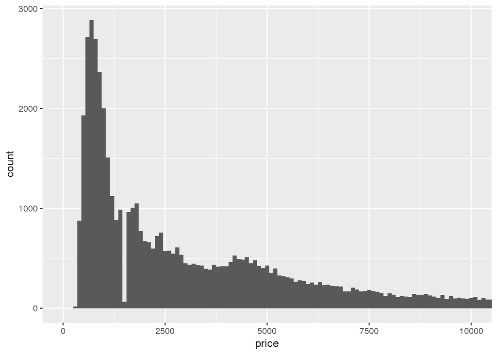

```r
#coor_cartesian
ggplot(data = diamonds) +
  geom_histogram(mapping = aes(x = price), binwidth = 100) +
  coord_cartesian(xlim = c(0, 10000))
```

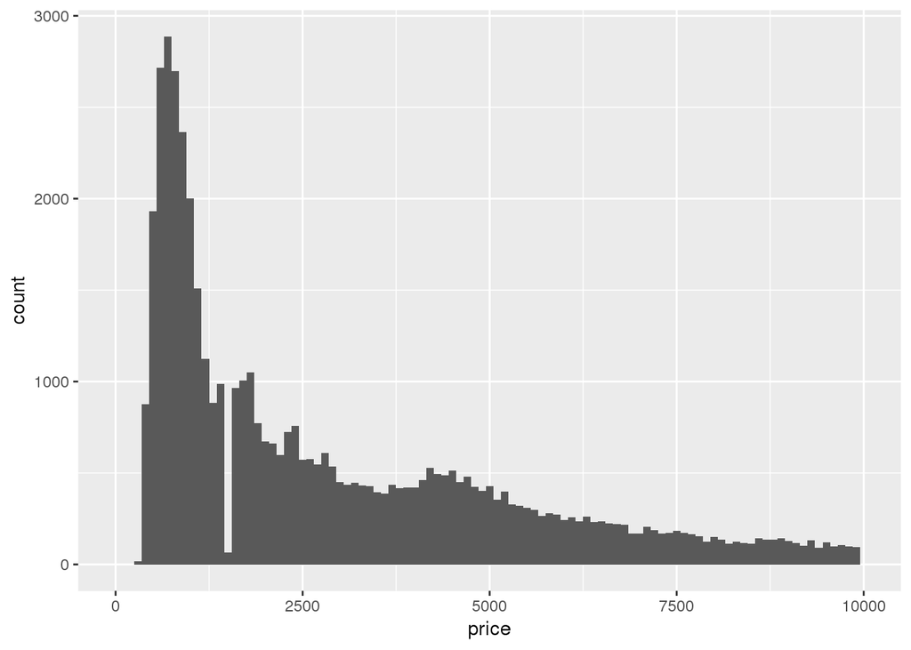

```r
#xlim()
ggplot(data = diamonds) +
  geom_histogram(mapping = aes(x = price), binwidth = 100) + xlim(0, 10000)
```

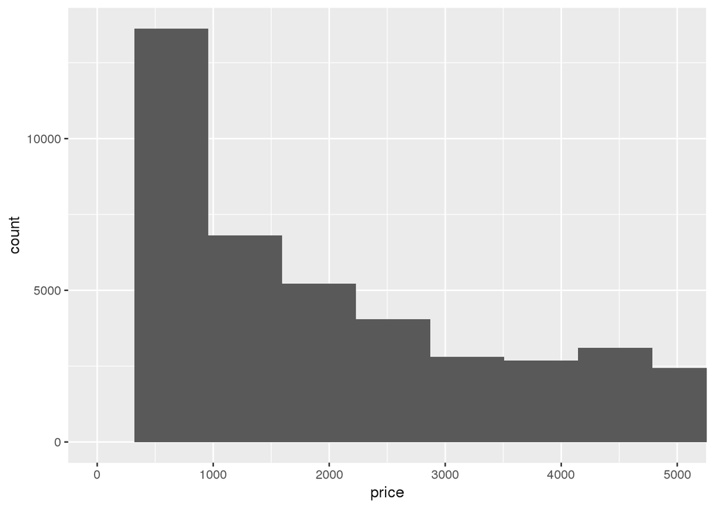

```r
#leave binwidth unset
ggplot(data = diamonds) +
  geom_histogram(mapping = aes(x = price)) +
  coord_cartesian(xlim = c(0, 5000))
```

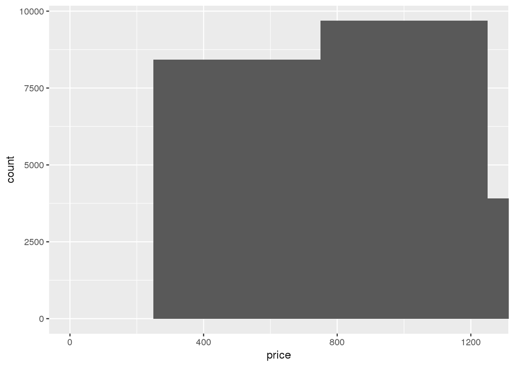

```r
#zoom so only half a bar shows
ggplot(data = diamonds) +
  geom_histogram(mapping = aes(x = price), binwidth = 500) +
  coord_cartesian(xlim = c(0, 1250))
```

Coor_cartesian and xlim() generate the same shape when zooming in on a histogram. The difference lies on how they process the zoom-in command. Coor_cartesian simply zoom in the data in the given limits (the histogram is not affected) while xlim() removes the data that fall outside of the boundary first, then calculate the histogram. When we leave binwidth unset, r studio uses bins = 30 as default setting. When the boundary cut at the middle of bin, rstudio shows only half a bar.

7.4.1 1.What happens to missing values in a histogram? What happens to missing values in a bar chart? Why is there a difference?

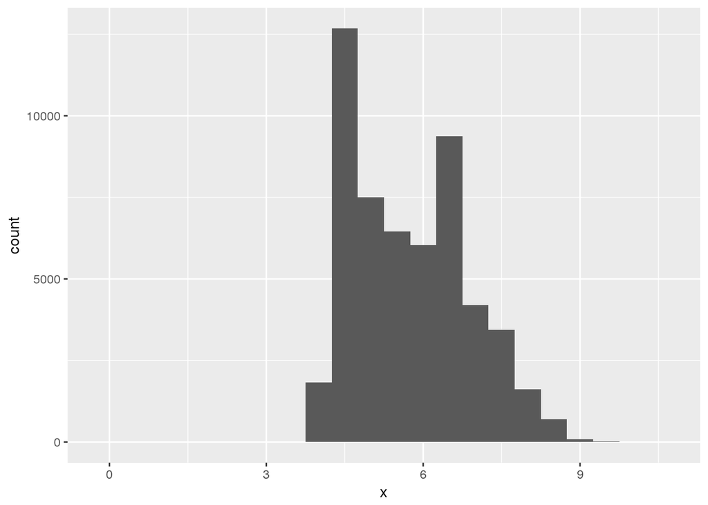

```r
#histogram
diamonds %>%
  mutate(x = ifelse(x < 3 | x > 15, NA, x)) %>%
  ggplot(data = diamonds, mapping = aes(x)) +
  geom_histogram(binwidth = 0.5)
```

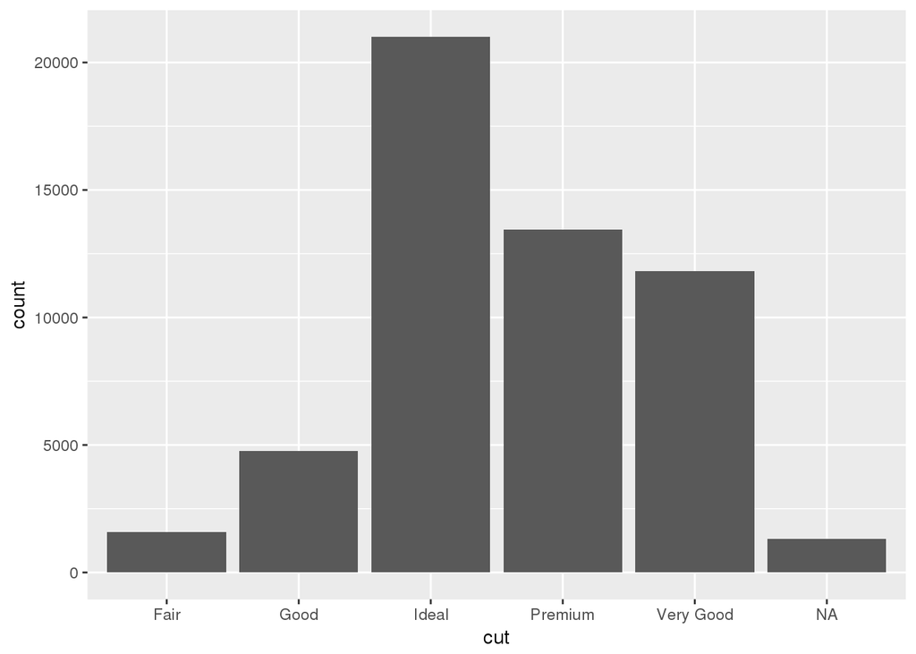

```r
#bar
diamonds %>%
  mutate(cut = if_else(rnorm(n()) < -1.96, NA_character_,
                       as.character((cut)))) %>%
  ggplot(diamonds, mapping = aes(x = cut)) +
  geom_bar()
```

2.What does na.rm = TRUE do in mean() and sum()?

```r
mean(c(1, 3, 6, NA, 7), na.rm = TRUE)
```

```
## [1] 4.25
```

```r
sum(c(5, 8, 2, NA, NA, 23), na.rm = TRUE)
```

```
## [1] 38
```

na.rm = TRUE removes the NA values before calculating mean and sum

7.5.1.1 1.Use what you’ve learned to improve the visualisation of the departure times of cancelled vs. non-cancelled flights.

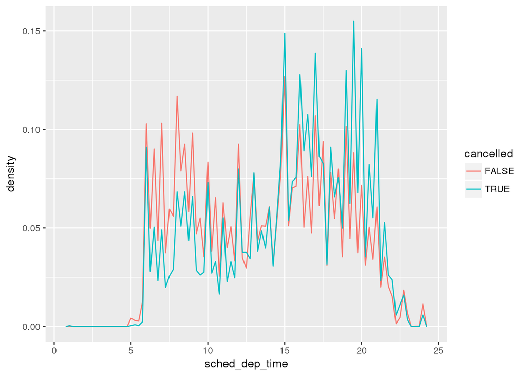

```r
#change count to density
nycflights13::flights %>%
  mutate(
    cancelled = is.na(dep_time),
    sched_hour = sched_dep_time %/% 100,
    sched_min = sched_dep_time %% 100,
    sched_dep_time = sched_hour + sched_min / 60
  ) %>%
  ggplot(mapping = aes(x = sched_dep_time, y = ..density..)) +
  geom_freqpoly(mapping = aes(colour = cancelled), binwidth = 1/4)
```

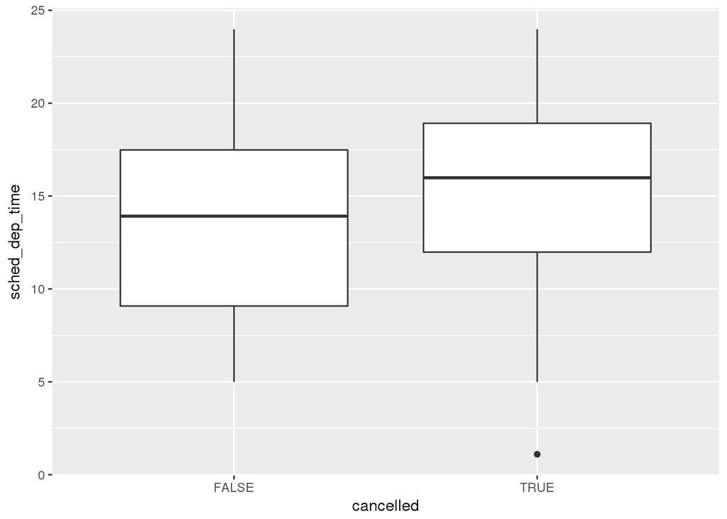

```r
#boxplot
nycflights13::flights %>%
  mutate(
    cancelled = is.na(dep_time),
    sched_hour = sched_dep_time %/% 100,
    sched_min = sched_dep_time %% 100,
    sched_dep_time = sched_hour + sched_min / 60
  ) %>%
  ggplot() +
  geom_boxplot(mapping = aes(x = cancelled, y = sched_dep_time))
```

We can see cancelled flights have a higher scheduled departure time than non-cancelled flights.

2.What variable in the diamonds dataset is most important for predicting the price of a diamond? How is that variable correlated with cut? Why does the combination of those two relationships lead to lower quality diamonds being more expensive?

```r
library(quantreg)
diamonds
```

```
## # A tibble: 53,940 x 10
##    carat cut       color clarity depth table price     x     y     z
##    <dbl> <ord>     <ord> <ord>   <dbl> <dbl> <int> <dbl> <dbl> <dbl>
##  1 0.230 Ideal     E     SI2      61.5  55.0   326  3.95  3.98  2.43
##  2 0.210 Premium   E     SI1      59.8  61.0   326  3.89  3.84  2.31
##  3 0.230 Good      E     VS1      56.9  65.0   327  4.05  4.07  2.31
##  4 0.290 Premium   I     VS2      62.4  58.0   334  4.20  4.23  2.63
##  5 0.310 Good      J     SI2      63.3  58.0   335  4.34  4.35  2.75
##  6 0.240 Very Good J     VVS2     62.8  57.0   336  3.94  3.96  2.48
##  7 0.240 Very Good I     VVS1     62.3  57.0   336  3.95  3.98  2.47
##  8 0.260 Very Good H     SI1      61.9  55.0   337  4.07  4.11  2.53
##  9 0.220 Fair      E     VS2      65.1  61.0   337  3.87  3.78  2.49
## 10 0.230 Very Good H     VS1      59.4  61.0   338  4.00  4.05  2.39
## # ... with 53,930 more rows
```

```
## Smoothing formula not specified. Using: y ~ x
```

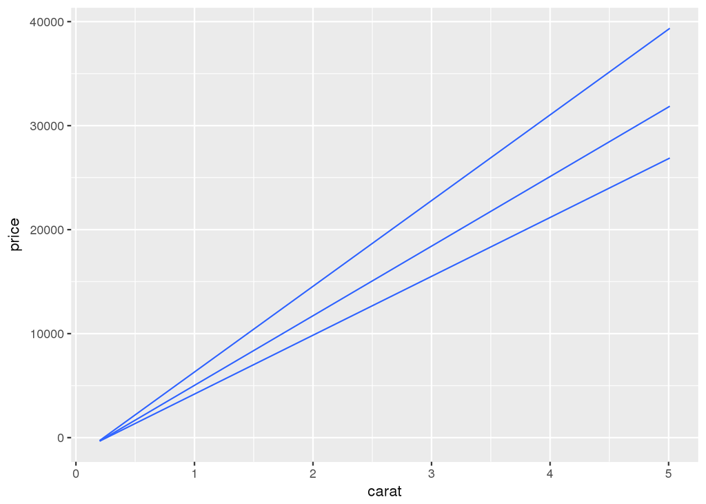

```r
#carat: y
diamonds %>%
  ggplot()+
  geom_quantile(mapping = aes(x = carat, y = price))
```

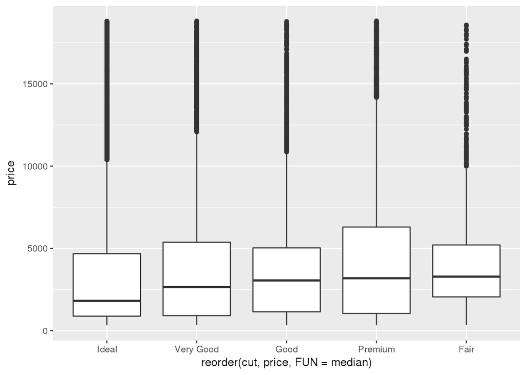

```r
#cut: n
diamonds %>%
  ggplot() +
  geom_boxplot(mapping = aes(x = reorder(cut, price, FUN = median), y = price))
```

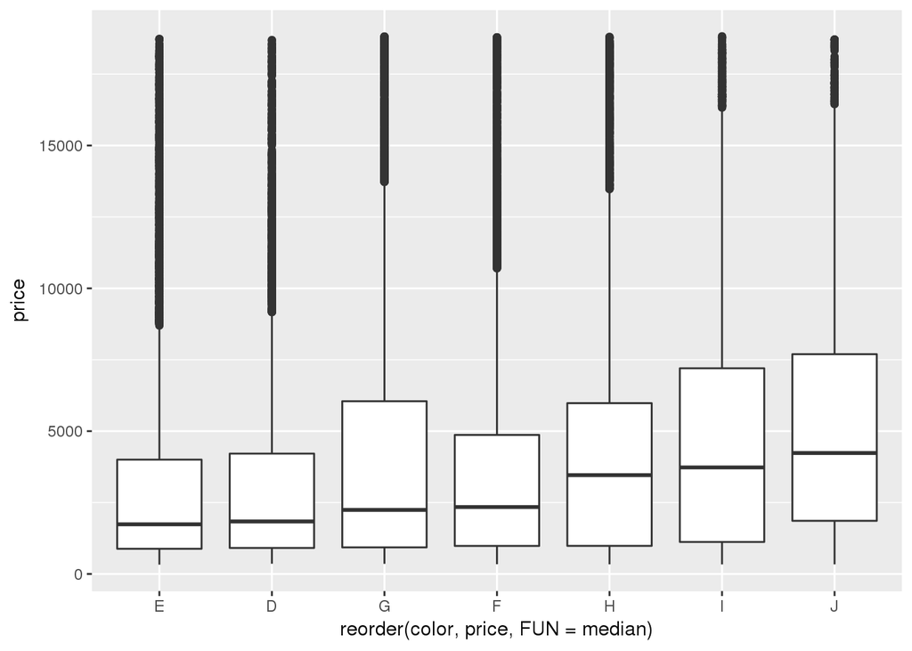

```r
#color: n
diamonds %>%
  ggplot() +
  geom_boxplot(mapping = aes(x = reorder(color, price, FUN = median),
                             y = price))
```

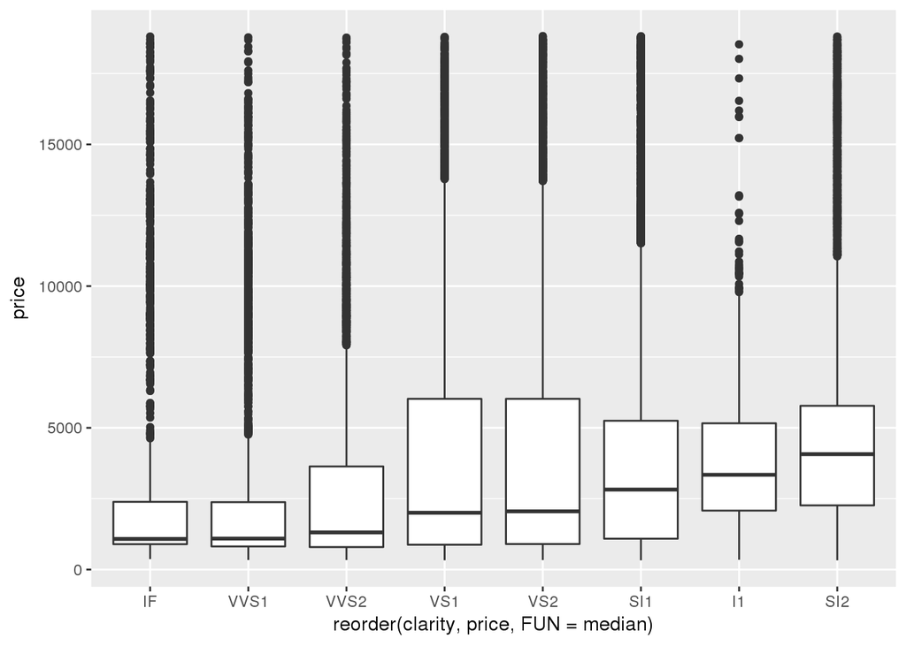

```r
#clarity:n
diamonds %>%
  ggplot() +
  geom_boxplot(mapping = aes(x = reorder(clarity, price, FUN = median),
                             y = price))
```

```
## Smoothing formula not specified. Using: y ~ x
```

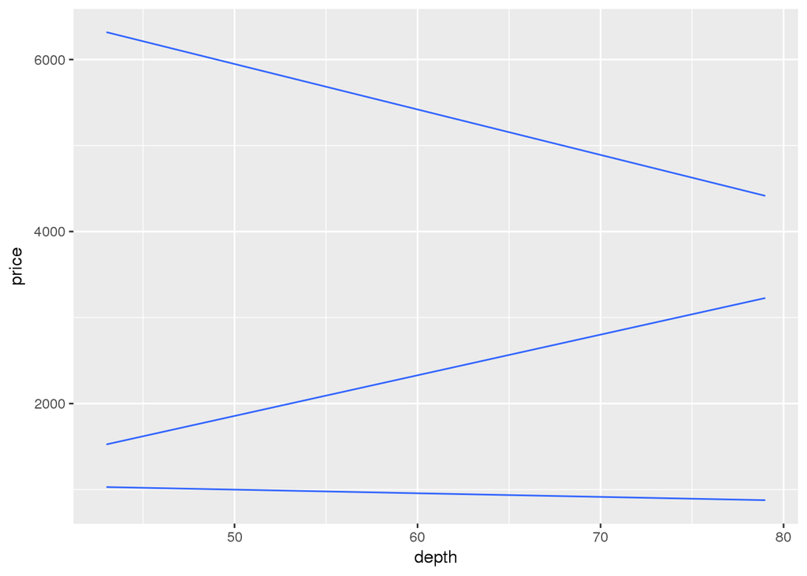

```r
#depth: n
diamonds %>%
  ggplot()+
  geom_quantile(mapping = aes(x = depth, y = price))
```

```
## Smoothing formula not specified. Using: y ~ x
```

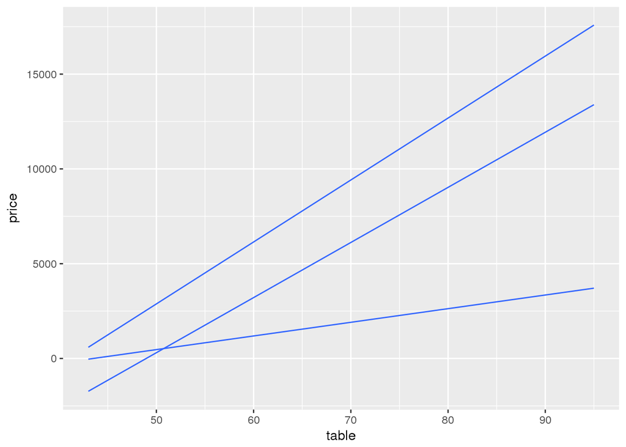

```r
#table: y
diamonds %>%
  ggplot()+
  geom_quantile(mapping = aes(x = table, y = price))
```

```
## Smoothing formula not specified. Using: y ~ x
```

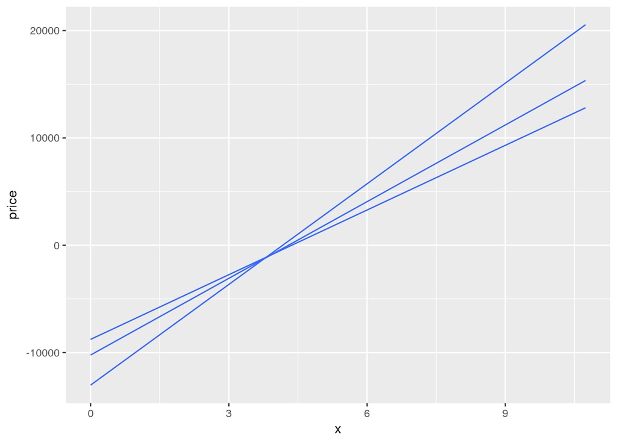

```r
#x: n
diamonds %>%
  ggplot()+
  geom_quantile(mapping = aes(x = x, y = price))
```

```
## Smoothing formula not specified. Using: y ~ x
```

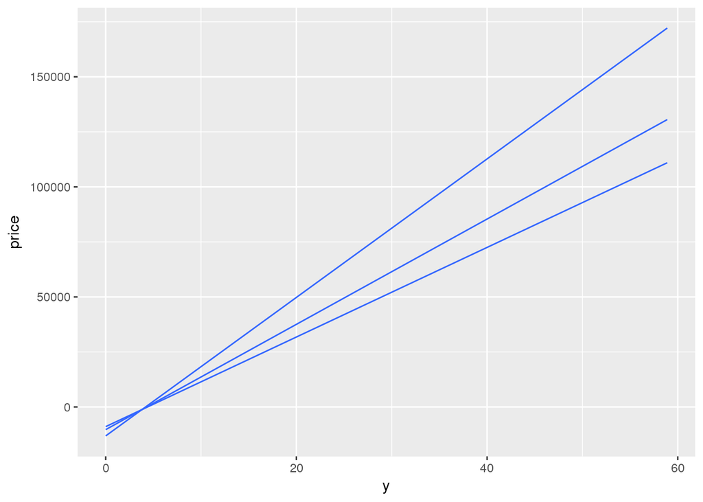

```r
#y: y
diamonds %>%
  ggplot()+
  geom_quantile(mapping = aes(x = y, y = price))
```

```
## Smoothing formula not specified. Using: y ~ x
```

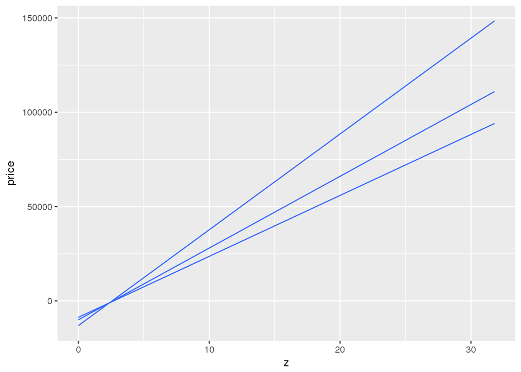

```r
#z: y
diamonds %>%
  ggplot()+
  geom_quantile(mapping = aes(x = z, y = price))
```

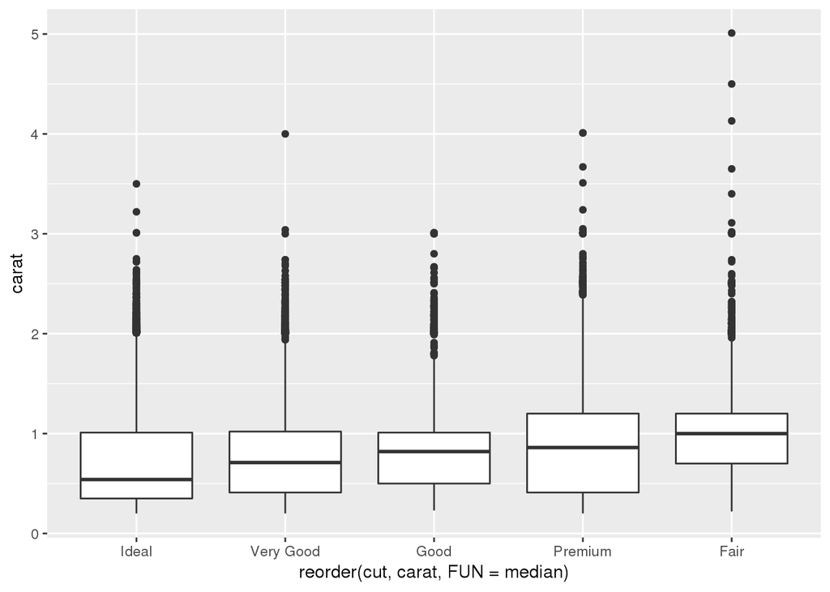

```r
#cut and carat:
diamonds %>%
  ggplot() +
  geom_boxplot(mapping = aes(x = reorder(cut, carat, FUN = median), y = carat))
```

Carat is the most important for predicting the price of a diamond. Carat and the price of the diamond have a positive relationship. When there is an increase in carat, the price of the diamond increases as well. We examined the relationship between cut and carat. We can see that the fair diamonds have higher carat in average, and higher carat is related to higher diamond price. The combination of these two relationship lead to lower quality diamonds being more expensive.